# Data Analysis Project: Knee Replacement Surgery

Analysis Proposal

Gitika Jain (gitikaj2)

Heather Sewak (hsewak2)

Ionel Miu (imiu2)

Jared Michael Coldert (jaredc2)

November 10, 2016

# Knee Replacement Surgery Outcome

## Description

Knee Replacement Surgery uses implants made from metal and high density polyethylene to replace a diseased or worn out knee joint. This dataset contains the details of a patient’s knee replacement surgery. The data includes the operating physician (converted to an integer value), anthropomorphic data about the patient, if computer navigation was utilized, the type of implants they received and two outcome metrics. The first metric is comprised of several measurements indicating how well the surgeon believes the knee is functioning after surgery. The second metric is a more subjective score measuring how well the patient is able to carry out daily activities.

## Background information

This data has been collected from a Southern California Hospital in collaboration with the Shiley Center for Orthopedic Research. The data is used for both clinical research and postoperative monitoring of implant survivorship. All patient specific information has been removed from the data so it adheres to the Health Insurance Portability and Accountability Act (HIPAA).

## Statement

We hope to determine the impact a particular surgeon or the type of implants used has on the patient’s outcome after surgery. We are also interested in exploring the potential relationship between anthropomorphic factors and the patient’s postoperative satisfaction. Finally, we would like to understand if the considerable expense of computer navigation in knee replacement leads to better postoperative scores. Nevertheless, we keep our option opened to investigate other aspects that were not ‘visibile’ or never thought about it but might reveal themselfs as we move on with the project.

Here we may consider *KneeScore_Surgeon* or *KennScore_Patient* as response and *Age, Gendar, Weight, Height, BMI, Race, Side, Manufacturer* as predictors. *Gendar, Race, Side and Manufacturer* are some of the categorical predictors and *Age, Height, Weight and BMI* are numerical predictors.

## Load Data in R

```r
plots = function(model) {
  par(mfcol=c(2,2))
  qqnorm(resid(model), col = red, pch = 16)
  qqline(resid(model), col = lightblue, lwd = 2)

  plot(fitted(model), resid(model), xlab = 'Fitted Values', ylab = 'Residuals', main = 'Fitted vs. Residuals Plot', col = purple, pch = 16)
  abline(h = 0, col = green, lwd = 2)

  hist(resid(model), col = blue, main = 'Histogram of Residuals', xlab = 'Residuals')
}

evaluate = function(model){

  # Run each of the tests
  shapiroTest = shapiro.test(resid(model))
  bpTest = bptest(model)
  rSquared = summary(model)$r.squared
  adjRSquared = summary(model)$adj.r.squared
  loocv = sqrt(mean((resid(model) / (1 - hatvalues(model))) ^ 2))
  large_lev = sum(hatvalues(model) > 2 * mean(hatvalues(model)))
  # gives percentage of large residuals (should be less than 5%)
  large_resid = sum(rstandard(model)[abs(rstandard(model)) > 2]) / length(resid(model))

  # Collect tests in dataframe
  values = data.frame(Result = c(prettyNum(shapiroTest$p.value), prettyNum(bpTest$p.value), prettyNum(rSquared), prettyNum(adjRSquared),        prettyNum(loocv), prettyNum(large_lev), prettyNum(large_resid)))
  rowNames = data.frame(Test = c('Shapiro Wilk pvalue', 'Breusch-Pagan pvalue', 'R Squared', 'Adj R Squared', 'Cross Validation', 'Large Leverages', 'Large Residuals'))

  summary_output = cbind(rowNames, values)
  # Add dataframe to matrix
  show(summary_output)
  plots(model)
}

removeLargeHatValues = function(model, data){
  values = hatvalues(model)
  index_ = which(values > (2 * mean(values)))
  newData = data[-c(index_),]
  return(newData)
}
```

```r
knee <- read.csv("knees.csv")
knee$Surgeon = as.factor(knee$Surgeon)
knee$Year = as.factor(knee$Year)
# dimensions of the dataset
dim(knee)
```

```
## [1] 1969   24
```

```r
# list the variables in dataset
names(knee)
```

```
##  [1] "Surgeon"               "Year"
##  [3] "Age"                   "Gender"
##  [5] "Weight"                "Height"
##  [7] "BMI"                   "Diagnosis"
##  [9] "Race"                  "Side"
## [11] "KneeScore_Surgeon"     "KneeScore_Patient"
## [13] "GPS"                   "Manufacturer"
## [15] "FemoralComponentModel" "FemoralComponentSize"
## [17] "FemoralComponentType"  "TibialTrayModel"
## [19] "TibialTraySize"        "TibialInsertModel"
## [21] "TibialInsertWidth"     "TibialInsertType"
## [23] "PatellaModel"          "PatellaDiameter"
```

```r
# list the structure of dataset
str(knee)
```

```
## 'data.frame':    1969 obs. of  24 variables:
##  $ Surgeon              : Factor w/ 5 levels "1","2","3","4",..: 1 3 2 1 1 4 3 4 1 2 ...
##  $ Year                 : Factor w/ 7 levels "2010","2011",..: 1 1 1 1 1 1 1 1 1 1 ...
##  $ Age                  : int  59 54 76 67 81 67 72 67 57 70 ...
##  $ Gender               : Factor w/ 2 levels "Female","Male": 1 1 1 1 1 1 1 1 1 1 ...
##  $ Weight               : int  155 189 200 165 155 148 130 205 210 150 ...
##  $ Height               : int  61 63 62 64 59 62 61 62 63 59 ...
##  $ BMI                  : num  29.3 33.5 36.6 28.4 31.3 ...
##  $ Diagnosis            : Factor w/ 9 levels "Avascular necrosis",..: 4 4 4 4 4 4 3 4 4 4 ...
##  $ Race                 : Factor w/ 10 levels "Asian","Black or African American",..: 7 2 3 10 10 10 10 10 3 3 ...
##  $ Side                 : Factor w/ 3 levels "Bilateral","Left",..: 1 2 2 2 3 3 3 3 3 3 ...
##  $ KneeScore_Surgeon    : int  33 0 49 53 66 56 47 36 33 30 ...
##  $ KneeScore_Patient    : int  0 5 35 50 65 80 60 80 20 50 ...
##  $ GPS                  : Factor w/ 2 levels "No","Yes": 1 1 1 1 1 1 1 1 1 1 ...
##  $ Manufacturer         : Factor w/ 4 levels "DePuy (J&J)",..: 2 2 3 2 2 3 1 3 2 3 ...
##  $ FemoralComponentModel: Factor w/ 16 levels "Attune","Genesis II",..: 4 4 14 4 4 14 12 14 2 14 ...
##  $ FemoralComponentSize : Factor w/ 27 levels "1","10","12",..: 8 6 6 8 8 4 5 4 6 1 ...
##  $ FemoralComponentType : Factor w/ 3 levels "constrained",..: 2 2 2 2 2 2 2 2 3 2 ...
##  $ TibialTrayModel      : Factor w/ 15 levels "Attune","Genesis II",..: 2 2 15 2 2 15 13 15 2 15 ...
##  $ TibialTraySize       : Factor w/ 17 levels "1","10","2","2.5",..: 3 3 3 3 3 3 3 3 3 3 ...
##  $ TibialInsertModel    : Factor w/ 23 levels "Advance","Attune",..: 7 7 22 4 4 21 15 21 4 21 ...
##  $ TibialInsertWidth    : num  11 11 9 11 11 9 8 13 13 9 ...
##  $ TibialInsertType     : Factor w/ 22 levels "Constrained",..: 9 9 2 9 19 19 3 19 9 2 ...
##  $ PatellaModel         : Factor w/ 12 levels "3-Post Round Dome",..: 3 3 12 3 3 12 1 12 3 12 ...
##  $ PatellaDiameter      : int  32 26 29 35 29 29 32 29 29 31 ...
```

```r
# list levels of factor Gender in dataset
levels(knee$Gender)
```

```
## [1] "Female" "Male"
```

```r
# print first 10 rows and 5 columns of dataset
head(knee[, 1: 5], n = 10)
```

```
##    Surgeon Year Age Gender Weight
## 1        1 2010  59 Female    155
## 2        3 2010  54 Female    189
## 3        2 2010  76 Female    200
## 4        1 2010  67 Female    165
## 5        1 2010  81 Female    155
## 6        4 2010  67 Female    148
## 7        3 2010  72 Female    130
## 8        4 2010  67 Female    205
## 9        1 2010  57 Female    210
## 10       2 2010  70 Female    150
```

### Investigate for a model to analyze Surgeon score response

```r
knee_model = lm(KneeScore_Surgeon ~ ., data = knee)
summary(knee_model)
```

```
##
## Call:
## lm(formula = KneeScore_Surgeon ~ ., data = knee)
##
## Residuals:
##     Min      1Q  Median      3Q     Max
## -43.928  -8.832  -0.234   7.798  49.165
##
## Coefficients: (21 not defined because of singularities)
##                                                             Estimate
## (Intercept)                                                 35.69897
## Surgeon2                                                    -0.45208
## Surgeon3                                                    -1.09966
## Surgeon4                                                    -2.11622
## Surgeon5                                                    -3.71883
## Year2011                                                     1.77031
## Year2012                                                     2.02319
## Year2013                                                    -0.52894
## Year2014                                                     3.04851
## Year2015                                                     2.75161
## Year2016                                                     4.20897
## Age                                                          0.28554
## GenderMale                                                   1.06471
## Weight                                                       0.05721
## Height                                                      -0.21788
## BMI                                                         -0.38019
## DiagnosisInflammatory  non-infection                        -9.50692
## DiagnosisInflammatory non-infection                        -13.35023
## DiagnosisOsteoarthritis                                      0.77431
## DiagnosisPaget's disease                                    18.53356
## DiagnosisPost-trauma                                        -4.33767
## DiagnosisPsoriatic Arthritis                                -8.02204
## DiagnosisRheumatoid arthritis                                7.64676
## DiagnosisRheumatoid arthritis, Inflammatory  non-infection   0.39754
## RaceBlack or African American                               -4.68131
## RaceHispanic                                                -8.44185
## RaceIndian Sub-Continent                                   -19.33729
## RaceMid-East Arabian                                        -2.16159
## RaceMultiple Races                                          -2.87781
## RaceOther                                                   -9.18859
```

[output cut: 640 more lines]

```
## PatellaModelNexGen                                           0.8957
## PatellaModelNexGen Legacy                                    0.7981
## PatellaModelOval Dome Patella 3-peg                          0.2825
## PatellaModelPatella Round Dome                               0.1281
## PatellaModelPersona                                              NA
## PatellaModelPFC Sigma                                        0.9638
## PatellaModelTriathlon                                        0.7821
## PatellaModelTriathlon Asymmetric Patella                     0.9936
## PatellaDiameter                                              0.3578
## ---
## Signif. codes:  0 '***' 0.001 '**' 0.01 '*' 0.05 '.' 0.1 ' ' 1
##
## Residual standard error: 14.11 on 1821 degrees of freedom
## Multiple R-squared:  0.2718, Adjusted R-squared:  0.2131
## F-statistic: 4.625 on 147 and 1821 DF,  p-value: < 2.2e-16
```

**NOTE:** *knee_model* returns NA for some coefficients. That means that those variables are linearly related to others.

```r
knee_model_aic = step(knee_model, direction = "backward", trace = 0)
summary(knee_model_aic)
```

```
##
## Call:
## lm(formula = KneeScore_Surgeon ~ Surgeon + Year + Age + Side +
##     KneeScore_Patient, data = knee)
##
## Residuals:
##     Min      1Q  Median      3Q     Max
## -45.979  -9.372  -0.414   8.198  55.202
##
## Coefficients:
##                   Estimate Std. Error t value Pr(>|t|)
## (Intercept)       11.87811    2.90141   4.094 4.41e-05 ***
## Surgeon2          -0.05837    1.21581  -0.048  0.96171
## Surgeon3          -0.26328    0.90425  -0.291  0.77096
## Surgeon4          -1.63041    0.90419  -1.803  0.07152 .
## Surgeon5          -3.36104    1.12516  -2.987  0.00285 **
## Year2011          -0.90002    1.24093  -0.725  0.46837
## Year2012          -1.20333    1.10568  -1.088  0.27659
## Year2013          -3.42579    1.11845  -3.063  0.00222 **
## Year2014           1.49211    1.31165   1.138  0.25544
## Year2015           3.03728    1.47493   2.059  0.03960 *
## Year2016           4.36096    2.73126   1.597  0.11050
## Age                0.29886    0.03595   8.313  < 2e-16 ***
## SideLeft           9.20556    0.84107  10.945  < 2e-16 ***
## SideRight          9.04404    0.82579  10.952  < 2e-16 ***
## KneeScore_Patient  0.26575    0.01686  15.759  < 2e-16 ***
## ---
## Signif. codes:  0 '***' 0.001 '**' 0.01 '*' 0.05 '.' 0.1 ' ' 1
##
## Residual standard error: 14.22 on 1954 degrees of freedom
## Multiple R-squared:  0.2062, Adjusted R-squared:  0.2005
## F-statistic: 36.26 on 14 and 1954 DF,  p-value: < 2.2e-16
```

```r
summary(knee_model_aic)$call
```

```
## lm(formula = KneeScore_Surgeon ~ Surgeon + Year + Age + Side +
##     KneeScore_Patient, data = knee)
```

**NOTE:** *knee_model_aic* returns a model without NA coefficients. That’s good as the algorithm was able to sense and eliminate those variables.

```r
n = nrow(knee)
knee_model_bic = step(knee_model, direction = "backward", trace = 0, k = log(n))
summary(knee_model_bic)
```

```
##
## Call:
## lm(formula = KneeScore_Surgeon ~ Age + Side + KneeScore_Patient,
##     data = knee)
##
## Residuals:
##     Min      1Q  Median      3Q     Max
## -46.221  -9.757  -0.456   8.563  56.830
##
## Coefficients:
##                   Estimate Std. Error t value Pr(>|t|)
## (Intercept)       11.51239    2.73228   4.213 2.63e-05 ***
## Age                0.28227    0.03596   7.850 6.79e-15 ***
## SideLeft           8.83061    0.83622  10.560  < 2e-16 ***
## SideRight          8.86419    0.82352  10.764  < 2e-16 ***
## KneeScore_Patient  0.26475    0.01694  15.625  < 2e-16 ***
## ---
## Signif. codes:  0 '***' 0.001 '**' 0.01 '*' 0.05 '.' 0.1 ' ' 1
##
## Residual standard error: 14.36 on 1964 degrees of freedom
## Multiple R-squared:  0.1869, Adjusted R-squared:  0.1853
## F-statistic: 112.9 on 4 and 1964 DF,  p-value: < 2.2e-16
```

```r
summary(knee_model_bic)$call
```

```
## lm(formula = KneeScore_Surgeon ~ Age + Side + KneeScore_Patient,
##     data = knee)
```

**NOTE:** *knee_model_bic* returns a model without NA coefficients, as well.  
Also, it uses fewer variables when compared to *knee_model_aic*.

```r
anova(knee_model_aic, knee_model)
```

```
## Analysis of Variance Table
##
## Model 1: KneeScore_Surgeon ~ Surgeon + Year + Age + Side + KneeScore_Patient
## Model 2: KneeScore_Surgeon ~ Surgeon + Year + Age + Gender + Weight +
##     Height + BMI + Diagnosis + Race + Side + KneeScore_Patient +
##     GPS + Manufacturer + FemoralComponentModel + FemoralComponentSize +
##     FemoralComponentType + TibialTrayModel + TibialTraySize +
##     TibialInsertModel + TibialInsertWidth + TibialInsertType +
##     PatellaModel + PatellaDiameter
##   Res.Df    RSS  Df Sum of Sq      F  Pr(>F)
## 1   1954 395140
## 2   1821 362468 133     32673 1.2342 0.04065 *
## ---
## Signif. codes:  0 '***' 0.001 '**' 0.01 '*' 0.05 '.' 0.1 ' ' 1
```

```r
anova(knee_model_bic, knee_model)
```

```
## Analysis of Variance Table
##
## Model 1: KneeScore_Surgeon ~ Age + Side + KneeScore_Patient
## Model 2: KneeScore_Surgeon ~ Surgeon + Year + Age + Gender + Weight +
##     Height + BMI + Diagnosis + Race + Side + KneeScore_Patient +
##     GPS + Manufacturer + FemoralComponentModel + FemoralComponentSize +
##     FemoralComponentType + TibialTrayModel + TibialTraySize +
##     TibialInsertModel + TibialInsertWidth + TibialInsertType +
##     PatellaModel + PatellaDiameter
##   Res.Df    RSS  Df Sum of Sq      F   Pr(>F)
## 1   1964 404744
## 2   1821 362468 143     42276 1.4853 0.000288 ***
## ---
## Signif. codes:  0 '***' 0.001 '**' 0.01 '*' 0.05 '.' 0.1 ' ' 1
```

**Note:** According to p-value, which is kind of small, the tendency is to reject the null. It all depends on the choise of level of confidence, alpha.

```r
anova(knee_model_bic, knee_model_aic)
```

```
## Analysis of Variance Table
##
## Model 1: KneeScore_Surgeon ~ Age + Side + KneeScore_Patient
## Model 2: KneeScore_Surgeon ~ Surgeon + Year + Age + Side + KneeScore_Patient
##   Res.Df    RSS Df Sum of Sq      F    Pr(>F)
## 1   1964 404744
## 2   1954 395140 10    9603.8 4.7492 9.366e-07 ***
## ---
## Signif. codes:  0 '***' 0.001 '**' 0.01 '*' 0.05 '.' 0.1 ' ' 1
```

**Note:** p-value is very small, therefore, null is rejected. Since these two models are nested (knee_model_bic is nested inside knee_model_aic) *knee_model_aic* offers improvments for the modeling.

```r
anova(knee_model_bic, knee_model_aic, knee_model)
```

```
## Analysis of Variance Table
##
## Model 1: KneeScore_Surgeon ~ Age + Side + KneeScore_Patient
## Model 2: KneeScore_Surgeon ~ Surgeon + Year + Age + Side + KneeScore_Patient
## Model 3: KneeScore_Surgeon ~ Surgeon + Year + Age + Gender + Weight +
##     Height + BMI + Diagnosis + Race + Side + KneeScore_Patient +
##     GPS + Manufacturer + FemoralComponentModel + FemoralComponentSize +
##     FemoralComponentType + TibialTrayModel + TibialTraySize +
##     TibialInsertModel + TibialInsertWidth + TibialInsertType +
##     PatellaModel + PatellaDiameter
##   Res.Df    RSS  Df Sum of Sq      F    Pr(>F)
## 1   1964 404744
## 2   1954 395140  10      9604 4.8249 6.968e-07 ***
## 3   1821 362468 133     32673 1.2342   0.04065 *
## ---
## Signif. codes:  0 '***' 0.001 '**' 0.01 '*' 0.05 '.' 0.1 ' ' 1
```

**Comments:** Corelating all the above, so far, *knee_model_aic* seems to offer the best model to analyze Surgeon Score

```r
evaluate(knee_model_bic)
```

```
##                   Test       Result
## 1  Shapiro Wilk pvalue 1.169168e-05
## 2 Breusch-Pagan pvalue 0.0001309477
## 3            R Squared    0.1869122
## 4        Adj R Squared    0.1852562
## 5     Cross Validation     14.37629
## 6      Large Leverages           87
## 7      Large Residuals   0.04983871
```

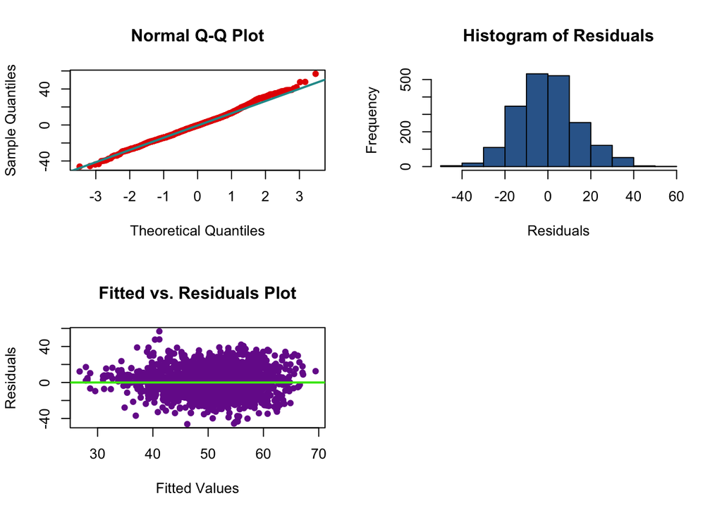

```r
new_data = removeLargeHatValues(knee_model_bic, knee)
knee_two = lm(KneeScore_Surgeon ~ ., data = new_data)
evaluate(knee_two)
```

```
##                   Test       Result
## 1  Shapiro Wilk pvalue 7.439593e-08
## 2 Breusch-Pagan pvalue    0.9561037
## 3            R Squared    0.2666205
## 4        Adj R Squared    0.2058222
## 5     Cross Validation          Inf
## 6      Large Leverages          174
## 7      Large Residuals           NA
```

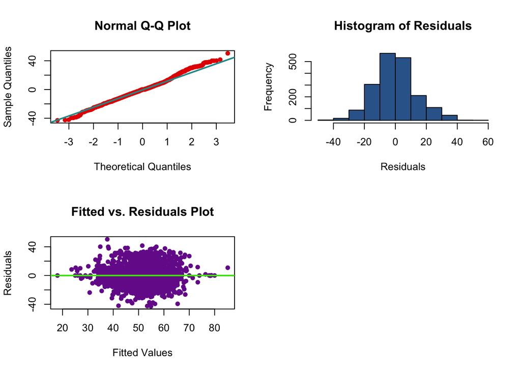

### Investigate for a model to analyze Patient score response

```r
knee_model = lm(KneeScore_Patient ~ ., data = knee)
summary(knee_model)
```

```
##
## Call:
## lm(formula = KneeScore_Patient ~ ., data = knee)
##
## Residuals:
##     Min      1Q  Median      3Q     Max
## -59.303  -7.985   0.508   9.719  43.999
##
## Coefficients: (21 not defined because of singularities)
##                                                              Estimate
## (Intercept)                                                 -1.915326
## Surgeon2                                                    -4.144830
## Surgeon3                                                    -0.854322
## Surgeon4                                                    -2.426119
## Surgeon5                                                    -6.078044
## Year2011                                                     0.783504
## Year2012                                                     0.369261
## Year2013                                                     2.649025
## Year2014                                                     1.494244
## Year2015                                                     2.363497
## Year2016                                                     4.402806
## Age                                                         -0.555454
## GenderMale                                                   4.448468
## Weight                                                      -0.160543
## Height                                                       0.786039
## BMI                                                          0.128127
## DiagnosisInflammatory  non-infection                        14.030251
## DiagnosisInflammatory non-infection                         13.374272
## DiagnosisOsteoarthritis                                     11.098191
## DiagnosisPaget's disease                                   -13.082069
## DiagnosisPost-trauma                                         8.004339
## DiagnosisPsoriatic Arthritis                                 1.236836
## DiagnosisRheumatoid arthritis                                4.033253
## DiagnosisRheumatoid arthritis, Inflammatory  non-infection   3.935282
## RaceBlack or African American                               -0.607807
## RaceHispanic                                                 0.189065
## RaceIndian Sub-Continent                                    14.501160
## RaceMid-East Arabian                                         5.956255
## RaceMultiple Races                                          22.119817
## RaceOther                                                   -4.308807
```

[output cut: 640 more lines]

```
## PatellaModelNexGen                                          0.93987
## PatellaModelNexGen Legacy                                   0.01797 *
## PatellaModelOval Dome Patella 3-peg                         0.99841
## PatellaModelPatella Round Dome                              0.99927
## PatellaModelPersona                                              NA
## PatellaModelPFC Sigma                                       0.31270
## PatellaModelTriathlon                                       0.02287 *
## PatellaModelTriathlon Asymmetric Patella                    0.00338 **
## PatellaDiameter                                             0.23825
## ---
## Signif. codes:  0 '***' 0.001 '**' 0.01 '*' 0.05 '.' 0.1 ' ' 1
##
## Residual standard error: 16.65 on 1821 degrees of freedom
## Multiple R-squared:  0.3161, Adjusted R-squared:  0.2609
## F-statistic: 5.727 on 147 and 1821 DF,  p-value: < 2.2e-16
```

**NOTE:** *knee_model* returns NA for some coefficients. That means that those variables are linearly related to others.

```r
knee_model_aic = step(knee_model, direction = "backward", trace = 0)
summary(knee_model_aic)
```

```
##
## Call:
## lm(formula = KneeScore_Patient ~ Surgeon + Age + Gender + Weight +
##     Height + Race + KneeScore_Surgeon + PatellaDiameter, data = knee)
##
## Residuals:
##     Min      1Q  Median      3Q     Max
## -56.717  -8.480   0.791  10.198  46.719
##
## Coefficients:
##                               Estimate Std. Error t value Pr(>|t|)
## (Intercept)                   17.34132    9.85234   1.760   0.0785 .
## Surgeon2                       0.10617    1.42729   0.074   0.9407
## Surgeon3                       1.22200    1.06975   1.142   0.2535
## Surgeon4                       1.65141    1.07393   1.538   0.1243
## Surgeon5                      -2.10837    1.31715  -1.601   0.1096
## Age                           -0.51569    0.04370 -11.802  < 2e-16 ***
## GenderMale                     6.77699    1.13227   5.985 2.56e-09 ***
## Weight                        -0.12952    0.01070 -12.108  < 2e-16 ***
## Height                         0.93708    0.14113   6.640 4.06e-11 ***
## RaceBlack or African American -0.45550    5.06219  -0.090   0.9283
## RaceHispanic                  -0.28168    4.35217  -0.065   0.9484
## RaceIndian Sub-Continent      13.32967   12.47853   1.068   0.2856
## RaceMid-East Arabian          10.14714   12.44857   0.815   0.4151
## RaceMultiple Races            19.23967   12.46024   1.544   0.1227
## RaceOther                     -0.87624    5.20662  -0.168   0.8664
## RacePacific Islander          12.52651   17.22008   0.727   0.4670
## RaceUnknown                   -6.88419    5.61952  -1.225   0.2207
## RaceWhite                      5.19280    3.72792   1.393   0.1638
## KneeScore_Surgeon              0.34998    0.02434  14.380  < 2e-16 ***
## PatellaDiameter                0.15144    0.06975   2.171   0.0300 *
## ---
## Signif. codes:  0 '***' 0.001 '**' 0.01 '*' 0.05 '.' 0.1 ' ' 1
##
## Residual standard error: 16.79 on 1949 degrees of freedom
## Multiple R-squared:  0.2563, Adjusted R-squared:  0.249
## F-statistic: 35.34 on 19 and 1949 DF,  p-value: < 2.2e-16
```

```r
summary(knee_model_aic)$call
```

```
## lm(formula = KneeScore_Patient ~ Surgeon + Age + Gender + Weight +
##     Height + Race + KneeScore_Surgeon + PatellaDiameter, data = knee)
```

**NOTE:** *knee_model_aic* returns a model without NA coefficients. That’s good as the algorithm was able to sense and eliminate those variables.

```r
n = nrow(knee)
knee_model_bic = step(knee_model, direction = "backward", trace = 0, k = log(n))
summary(knee_model_bic)
```

```
##
## Call:
## lm(formula = KneeScore_Patient ~ Age + Gender + Weight + Height +
##     KneeScore_Surgeon, data = knee)
##
## Residuals:
##     Min      1Q  Median      3Q     Max
## -55.683  -8.534   0.847  10.273  45.962
##
## Coefficients:
##                   Estimate Std. Error t value Pr(>|t|)
## (Intercept)       18.09853    9.24114   1.958   0.0503 .
## Age               -0.51543    0.04313 -11.950  < 2e-16 ***
## GenderMale         6.81993    1.11173   6.135 1.03e-09 ***
## Weight            -0.13249    0.01066 -12.430  < 2e-16 ***
## Height             1.08936    0.13679   7.964 2.80e-15 ***
## KneeScore_Surgeon  0.35258    0.02437  14.469  < 2e-16 ***
## ---
## Signif. codes:  0 '***' 0.001 '**' 0.01 '*' 0.05 '.' 0.1 ' ' 1
##
## Residual standard error: 16.88 on 1963 degrees of freedom
## Multiple R-squared:  0.2423, Adjusted R-squared:  0.2404
## F-statistic: 125.6 on 5 and 1963 DF,  p-value: < 2.2e-16
```

```r
summary(knee_model_bic)$call
```

```
## lm(formula = KneeScore_Patient ~ Age + Gender + Weight + Height +
##     KneeScore_Surgeon, data = knee)
```

**NOTE:** *knee_model_bic* returns a model without NA coefficients, as well.  
Also, it uses fewer variables when compared to *knee_model_aic*.

```r
anova(knee_model_aic, knee_model)
```

```
## Analysis of Variance Table
##
## Model 1: KneeScore_Patient ~ Surgeon + Age + Gender + Weight + Height +
##     Race + KneeScore_Surgeon + PatellaDiameter
## Model 2: KneeScore_Patient ~ Surgeon + Year + Age + Gender + Weight +
##     Height + BMI + Diagnosis + Race + Side + KneeScore_Surgeon +
##     GPS + Manufacturer + FemoralComponentModel + FemoralComponentSize +
##     FemoralComponentType + TibialTrayModel + TibialTraySize +
##     TibialInsertModel + TibialInsertWidth + TibialInsertType +
##     PatellaModel + PatellaDiameter
##   Res.Df    RSS  Df Sum of Sq      F  Pr(>F)
## 1   1949 549248
## 2   1821 505034 128     44214 1.2455 0.03679 *
## ---
## Signif. codes:  0 '***' 0.001 '**' 0.01 '*' 0.05 '.' 0.1 ' ' 1
```

**Note:** According to p-value, which is NOT big enough, the tendency is to reject the null. Rejection vs not rejection depends on the choice of level of significance, alpha.

```r
anova(knee_model_bic, knee_model)
```

```
## Analysis of Variance Table
##
## Model 1: KneeScore_Patient ~ Age + Gender + Weight + Height + KneeScore_Surgeon
## Model 2: KneeScore_Patient ~ Surgeon + Year + Age + Gender + Weight +
##     Height + BMI + Diagnosis + Race + Side + KneeScore_Surgeon +
##     GPS + Manufacturer + FemoralComponentModel + FemoralComponentSize +
##     FemoralComponentType + TibialTrayModel + TibialTraySize +
##     TibialInsertModel + TibialInsertWidth + TibialInsertType +
##     PatellaModel + PatellaDiameter
##   Res.Df    RSS  Df Sum of Sq      F   Pr(>F)
## 1   1963 559528
## 2   1821 505034 142     54494 1.3837 0.002592 **
## ---
## Signif. codes:  0 '***' 0.001 '**' 0.01 '*' 0.05 '.' 0.1 ' ' 1
```

**Note:** According to p-value, which is kind of small, the tendency is to reject the null. It all depends on the choise of level of confidence, alpha.

```r
anova(knee_model_bic, knee_model_aic)
```

```
## Analysis of Variance Table
##
## Model 1: KneeScore_Patient ~ Age + Gender + Weight + Height + KneeScore_Surgeon
## Model 2: KneeScore_Patient ~ Surgeon + Age + Gender + Weight + Height +
##     Race + KneeScore_Surgeon + PatellaDiameter
##   Res.Df    RSS Df Sum of Sq      F    Pr(>F)
## 1   1963 559528
## 2   1949 549248 14     10279 2.6054 0.0009571 ***
## ---
## Signif. codes:  0 '***' 0.001 '**' 0.01 '*' 0.05 '.' 0.1 ' ' 1
```

**Note:** p-value is small(not aggressively small , though) suggesting to reject the null. That means that *knee_model_aic* offers improvments for the modeling.

```r
anova(knee_model_bic, knee_model_aic, knee_model)
```

```
## Analysis of Variance Table
##
## Model 1: KneeScore_Patient ~ Age + Gender + Weight + Height + KneeScore_Surgeon
## Model 2: KneeScore_Patient ~ Surgeon + Age + Gender + Weight + Height +
##     Race + KneeScore_Surgeon + PatellaDiameter
## Model 3: KneeScore_Patient ~ Surgeon + Year + Age + Gender + Weight +
##     Height + BMI + Diagnosis + Race + Side + KneeScore_Surgeon +
##     GPS + Manufacturer + FemoralComponentModel + FemoralComponentSize +
##     FemoralComponentType + TibialTrayModel + TibialTraySize +
##     TibialInsertModel + TibialInsertWidth + TibialInsertType +
##     PatellaModel + PatellaDiameter
##   Res.Df    RSS  Df Sum of Sq      F    Pr(>F)
## 1   1963 559528
## 2   1949 549248  14     10279 2.6475 0.0007875 ***
## 3   1821 505034 128     44214 1.2455 0.0367871 *
## ---
## Signif. codes:  0 '***' 0.001 '**' 0.01 '*' 0.05 '.' 0.1 ' ' 1
```

**Note:** Again, modeling all three models at once, p-value is small for *knee_model_aic*, therefore, null is rejected. Whereas *knee_model* does not reject the null unless we choose level of confidence, alpha = 0.05.

**Comments:** Corelating all the above, so far, *knee_model_aic* seems to offer the best model.

```r
evaluate(knee_model_bic)
```

```
##                   Test       Result
## 1  Shapiro Wilk pvalue 1.934109e-15
## 2 Breusch-Pagan pvalue 7.743929e-07
## 3            R Squared    0.2423439
## 4        Adj R Squared    0.2404141
## 5     Cross Validation     16.91178
## 6      Large Leverages          112
## 7      Large Residuals  -0.07589005
```

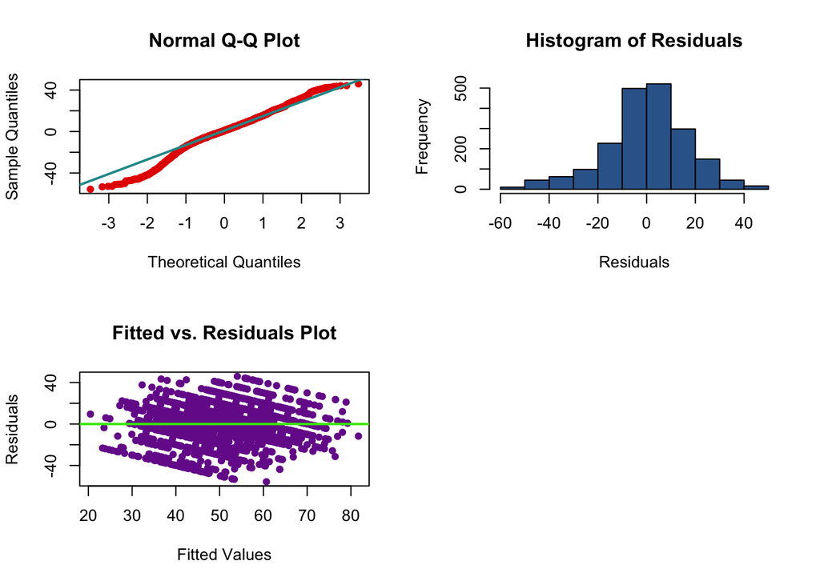

```r
new_data = removeLargeHatValues(knee_model_bic, knee)
knee_two = lm(KneeScore_Patient ~ ., data = new_data)
evaluate(knee_two)
```

```
##                   Test       Result
## 1  Shapiro Wilk pvalue 2.223687e-14
## 2 Breusch-Pagan pvalue    0.9886082
## 3            R Squared    0.2957434
## 4        Adj R Squared    0.2373978
## 5     Cross Validation          Inf
## 6      Large Leverages          169
## 7      Large Residuals           NA
```

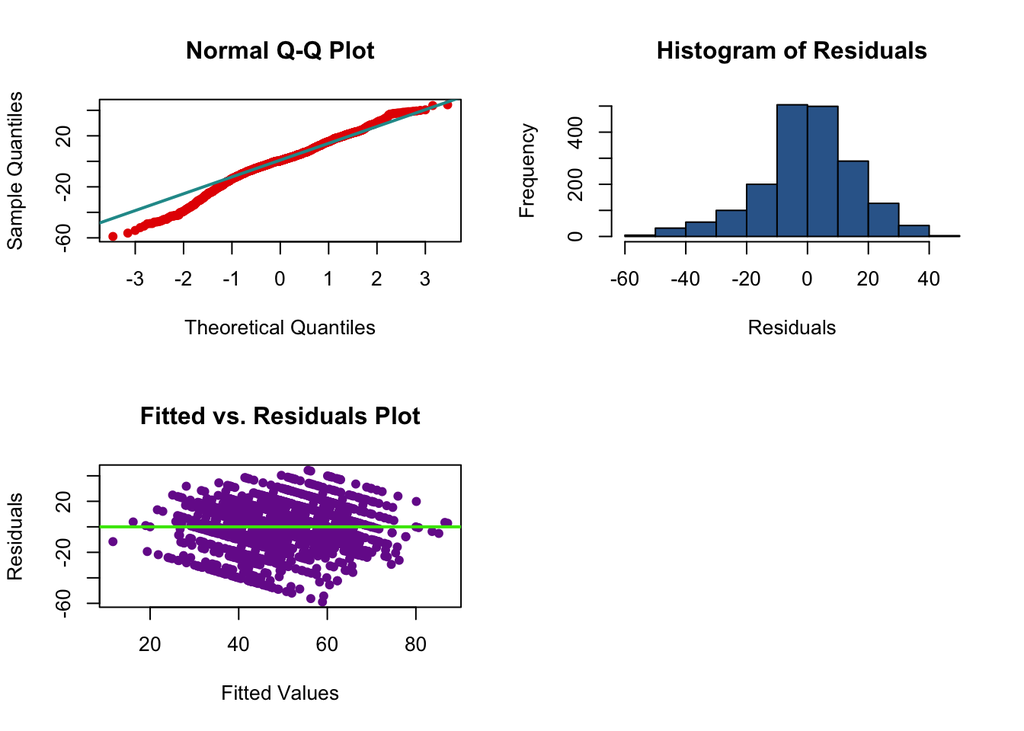

### Correlation between KneeScore_Patient and KneeScore_Surgeon

```r
round(cor(knee$KneeScore_Surgeon, knee$KneeScore_Patient), 2)
```

```
## [1] 0.29
```

**Note:** We have a very week correlation between Patient score and Surgeon score. Why? Shouldn’t they be the same or very similar?

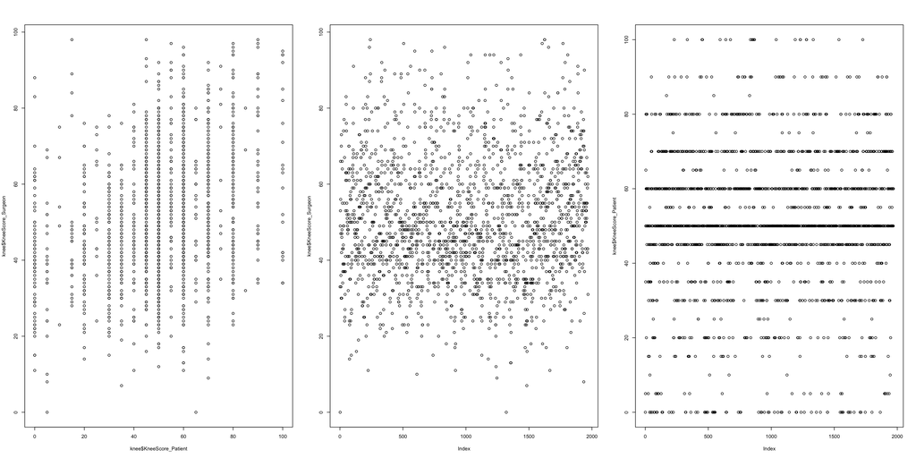

```r
par(mfrow=c(1,3))
plot(knee$KneeScore_Patient, knee$KneeScore_Surgeon)
plot(knee$KneeScore_Surgeon)
#par(new=T)
plot(knee$KneeScore_Patient)
```

```r
#plot(knee$KneeScore_Patient, col = "red", add=TRUE)
```

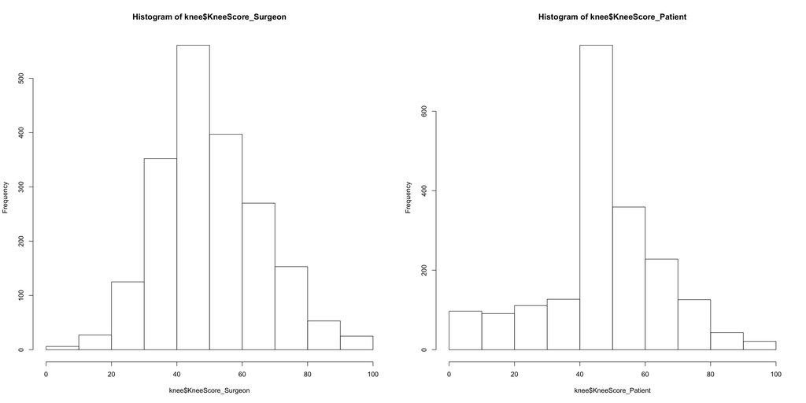

```r
par(mfrow=c(1,2))
hist(knee$KneeScore_Surgeon)
hist(knee$KneeScore_Patient)
```

##### Model selection

```r
lm(formula = KneeScore_Patient ~ Year + Age + Gender + Weight +
    Height + Race + KneeScore_Surgeon + TibialInsertWidth + PatellaDiameter,
    data = knee)
```

```
##
## Call:
## lm(formula = KneeScore_Patient ~ Year + Age + Gender + Weight +
##     Height + Race + KneeScore_Surgeon + TibialInsertWidth + PatellaDiameter,
##     data = knee)
##
## Coefficients:
##                   (Intercept)                       Year2011
##                       19.9892                         1.1222
##                      Year2012                       Year2013
##                        2.1553                         3.7251
##                      Year2014                       Year2015
##                        1.5194                         1.1137
##                      Year2016                            Age
##                        4.6055                        -0.5281
##                    GenderMale                         Weight
##                        6.9193                        -0.1275
##                        Height  RaceBlack or African American
##                        0.9266                         0.2682
##                  RaceHispanic       RaceIndian Sub-Continent
##                       -0.2843                        13.2945
##          RaceMid-East Arabian             RaceMultiple Races
##                       10.4677                        21.0788
##                     RaceOther           RacePacific Islander
##                        0.1900                        11.4864
##                   RaceUnknown                      RaceWhite
##                       -6.8952                         4.9099
##             KneeScore_Surgeon              TibialInsertWidth
##                        0.3554                        -0.2906
##               PatellaDiameter
##                        0.1458
```